# Predicting Red Wine Quality

Ridge regression, nearest neighbors, and the bias–variance tradeoff

November 1, 2026 - Submission

# 1 Research question and design

**Can chemical measurements predict a red wine’s sensory quality, and does a flexible local model outperform a regularized linear model?** I compare two methods permitted by the assignment: **linear regression with ridge regularization** and **k-nearest-neighbor (kNN) regression**. An ordinary least squares model and a training-mean predictor provide reference points.

I chose the red-wine portion of the [UCI Wine Quality dataset](https://archive.ics.uci.edu/dataset/186/wine+quality). It has a manageable sample size, numerical predictors on very different scales, and correlated measurements. These properties make scaling, shrinkage, and model complexity meaningful. Qulity is an ordered score. Regression preserves that ordering and penalizes large errors more heavily, while assuming equal spacing between adjacent scores. The goal is prediction, not a causal claim about changing a wine’s chemistry.

The original contribution is a from-scratch implementation of both models, repeated cross-validation with scaling learned inside each fold, and a split that prevents identical chemical prfiles from appearing on both sides of a training/validation boundary. The final model is chosen using training-set cross-validation before the held-out test set is scored.

# 2 Data, source, and quality checks

The data creators are Paulo Cortez, A. Cerdeira, F. Almeida, T. Matos, and J. Reis (2009). The red-wine file contains **1,599 observations, 11 chemical predictors, and one sensory quality score**. It concerns Portuguese red Vinho Verde wines. The documented score scale is 0–10; the observed range is checked below. The source documentation describes the score as the median of at least three expert evaluations. UCI distributes the dataset under CC BY 4.0.

The original semicolon-delimited dataset, `winequality-red.csv`, is included with this project. No internet connection is needed to rerun the analysis.

The next chunk reads the original file, verifies the schema, and constructs a profile identifier from the predictors alone. It does not silently remove outliers or repeated rows. Repeated profiles may represent duplicate entries or separate samples; without sample identifiers, their origin is uncertain. Keeping their rows together is a conservative way to prevent exact-profile leakage while preserving the dataset’s original observation weights.

```r
# read.csv2 uses semicolons but expects comma decimals, so specify read.csv.
wine <- read.csv("winequality-red.csv", sep = ";", check.names = TRUE)
predictors <- setdiff(names(wine), "quality")
stopifnot(nrow(wine) == 1599L, length(predictors) == 11L,
          all(vapply(wine, is.numeric, logical(1))), !anyNA(wine),
          all(is.finite(as.matrix(wine))), all(wine$quality %in% 0:10))

# A profile ignores quality so even matching inputs with differing labels
# must stay together. Each unique profile receives an integer group ID.
profile_key <- do.call(paste, c(wine[predictors], sep = "|"))
group_id <- match(profile_key, unique(profile_key))
audit <- data.frame(
  Check = c("Rows", "Predictors", "Missing cells", "Exact repeated rows",
            "Repeated predictor profiles beyond the first", "Unique profiles",
            "Minimum quality", "Maximum quality"),
  Value = c(nrow(wine), length(predictors), sum(is.na(wine)),
            sum(duplicated(wine)), sum(duplicated(profile_key)),
            length(unique(group_id)), min(wine$quality), max(wine$quality)))
knitr::kable(audit, caption = "Data audit (all rows; no fitted preprocessing).")
```

Data audit (all rows; no fitted preprocessing).

| Check | Value |
| --- | --- |
| Rows | 1599 |
| Predictors | 11 |
| Missing cells | 0 |
| Exact repeated rows | 240 |
| Repeated predictor profiles beyond the first | 240 |
| Unique profiles | 1359 |
| Minimum quality | 3 |
| Maximum quality | 8 |

There are 240 exact repeated rows and 1359 unique chemical profiles. A naive row-wise split could place identical inputs in training and testing, especially benefiting nearest neighbors. All splits in this analysis operate on the profile groups. All numerical values are finte and none are missing, so imputation is unnecessary. Unusual measurements are retained because no documented error rule justifies removing them.

| Variable | Role / meaning |
| --- | --- |
| fixed.acidity, volatile.acidity, citric.acid | Acidity measurements |
| residual.sugar | Residual sugar measurement |
| chlorides | Chloride measurement |
| free.sulfur.dioxide, total.sulfur.dioxide | Free and total sulfur dioxide |
| density | Wine density |
| pH | Acidity on the pH scale |
| sulphates | Sulphate measurement |
| alcohol | Alcohol measurement |
| quality | Target: sensory score, documented 0–10 scale |

## 2.1 Hold-out split before exploratory analysis

I randomly reserve 20% of the unique profiles for testing and use the remaining 80% for training and tuning. The percentages of rows can differ slightly from 80/20 because groups have different sizes. Test outcomes do not influence feature exploration, scaling, model selection, or tuning. A random split estimates performance on similar unseen profiles; it does not evaluate future vintages or a different geographic region.

```r
# Fixing the seed makes the same group allocation reproducible.
set.seed(402)
all_groups <- sort(unique(group_id))
train_groups <- sample(all_groups, floor(0.80 * length(all_groups)))
in_train <- group_id %in% train_groups
train <- wine[in_train, , drop = FALSE]
test <- wine[!in_train, , drop = FALSE]
g_train <- group_id[in_train]
g_test <- group_id[!in_train]
stopifnot(length(intersect(g_train, g_test)) == 0L)

# Preserve row identifiers and allocation so the split can be audited.
split_file <- data.frame(row_id = seq_len(nrow(wine)), group_id = group_id,
                         split = ifelse(in_train, "train", "test"))
write.csv(split_file, "results/split_assignments.csv", row.names = FALSE)
knitr::kable(data.frame(
  Split = c("Training", "Test"), Rows = c(nrow(train), nrow(test)),
  Profiles = c(length(unique(g_train)), length(unique(g_test)))),
  caption = "The test set remains outside all tuning.")
```

The test set remains outside all tuning.

| Split | Rows | Profiles |
| --- | --- | --- |
| Training | 1274 | 1087 |
| Test | 325 | 272 |

## 2.2 Training-set exploration

The distribution plot shows whether the response is balanced across scores. The correlation plot uses predictors only and helps motivate ridge regression: correlated columns can make unregularized coefficients sensitive to the sample. Neither plot establishes causation.

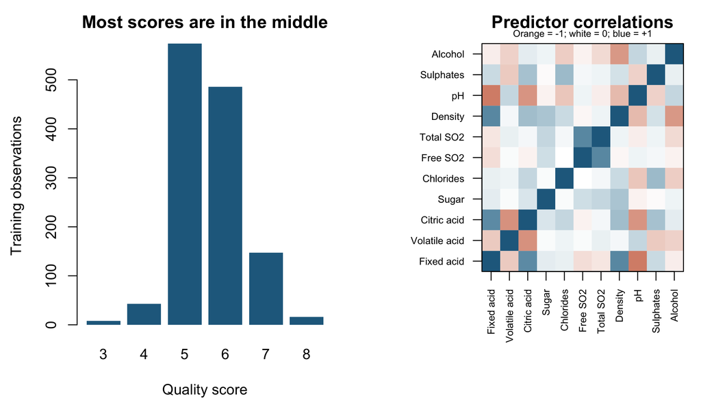

Training-set quality distribution and predictor correlations.

```r
# Use training rows for all exploratory plots. Correlations do not rescale data.
par(mfrow = c(1, 2), mar = c(4.3, 4.4, 2.5, 1))
barplot(table(factor(train$quality, levels = 3:8)), col = blue, border = NA,
        xlab = "Quality score", ylab = "Training observations",
        main = "Most scores are in the middle")
corr <- cor(train[predictors])
short_names <- c("Fixed acid", "Volatile acid", "Citric acid", "Sugar",
                 "Chlorides", "Free SO2", "Total SO2", "Density", "pH",
                 "Sulphates", "Alcohol")
par(mar = c(7.5, 7.5, 2.5, 1))
image(seq_along(predictors), seq_along(predictors), corr,
      zlim = c(-1, 1), col = colorRampPalette(c(orange, "white", blue))(101),
      axes = FALSE, xlab = "", ylab = "", main = "Predictor correlations")
mtext("Orange = -1; white = 0; blue = +1", side = 3, line = .2, cex = .65)
axis(1, at = seq_along(predictors), labels = short_names, las = 2, cex.axis = .68)
axis(2, at = seq_along(predictors), labels = short_names, las = 2, cex.axis = .68)
box()
```

```r
par(mfrow = c(1, 1))

# Report the strongest pair by absolute correlation, excluding the diagonal.
pair_index <- which(upper.tri(corr), arr.ind = TRUE)
pair_index <- pair_index[which.max(abs(corr[pair_index])), ]
top_pair <- predictors[pair_index]
top_correlation <- corr[pair_index[1], pair_index[2]]
training_summary <- data.frame(
  Variable = names(train), Minimum = sapply(train, min),
  Mean = sapply(train, mean), SD = sapply(train, sd), Maximum = sapply(train, max))
knitr::kable(training_summary, digits = 3, row.names = FALSE,
             caption = "Training-set descriptive statistics in original units.")
```

Training-set descriptive statistics in original units.

| Variable | Minimum | Mean | SD | Maximum |
| --- | --- | --- | --- | --- |
| fixed.acidity | 4.600 | 8.311 | 1.736 | 15.900 |
| volatile.acidity | 0.120 | 0.524 | 0.178 | 1.240 |
| citric.acid | 0.000 | 0.273 | 0.192 | 1.000 |
| residual.sugar | 0.900 | 2.526 | 1.371 | 15.500 |
| chlorides | 0.012 | 0.087 | 0.048 | 0.611 |
| free.sulfur.dioxide | 1.000 | 15.836 | 10.398 | 72.000 |
| total.sulfur.dioxide | 6.000 | 46.655 | 33.510 | 289.000 |
| density | 0.990 | 0.997 | 0.002 | 1.003 |
| pH | 2.740 | 3.308 | 0.153 | 4.010 |
| sulphates | 0.330 | 0.657 | 0.175 | 2.000 |
| alcohol | 8.400 | 10.424 | 1.067 | 14.900 |
| quality | 3.000 | 5.604 | 0.807 | 8.000 |

Scores 5 and 6 account for 83.2% of training observations. Consequently, a model can obtain a reasonable overall error while performing poorly on rare low or high scores. The strongest absolute predictor correlation is between fixed.acidity and pH (-0.675). The standard deviations also vary considerably across columns, so unscaled Euclidean distances would favor large-scale variables.

# 3 Methods and their implementation

## 3.1 Training-only standardization

Each predictor is transformed to `(x - training mean) / training SD`. Ridge needs comparable predictor scales because its penalty acts on coefficients; kNN needs them because distance determines the neighbors. In cross-validation, the mean and standard deviation come only from the fold’s analysis rows, then the same transformation is applied to validation rows. For the final fit, they come from the full training set. The response is not standardized.

```r
# Store the fitted transformation separately from applying it to new rows.
fit_scaler <- function(x) {
  center <- colMeans(x)
  spread <- apply(x, 2, sd)
  stopifnot(all(is.finite(spread)), all(spread > 0))
  list(center = center, spread = spread)
}
apply_scaler <- function(x, scaler) {
  sweep(sweep(as.matrix(x), 2, scaler$center, "-"),
        2, scaler$spread, "/")
}
```

## 3.2 Ridge regression: a regularized linear model

Ridge minimizes **mean squared training error + lambda × sum of squared slopes**. The intercept is unpenalized. With centered responses and standardized predictors, its slopes are obtained by solving `(Z'Z/n + lambda I) beta = Z'(y - mean(y))/n`. Dividing the loss by `n` makes the penalty convention explicit. A package with a different loss convention may report a different numerical lambda for the same fit. At lambda = 0, this is ordinary least squares. Larger lambda shrinks the slopes toward zero, usually increasing bias and reducing variance. Ridge keeps all predictors; it does not perform subset selction.

The function below fits an entire lambda grid. `crossprod` computes matrix products efficiently, and `solve(A, b)` solves a linear system without forming an explicit inverse. Centering the response lets the intercept be recovered as the training mean when predictors are standardized with training statistics.

```r
ridge_path <- function(z, y, newz, lambdas) {
  n <- nrow(z)
  p <- ncol(z)
  y_mean <- mean(y)
  gram <- crossprod(z) / n
  rhs <- crossprod(z, y - y_mean) / n

  # Each column contains one fitted model's standardized slopes.
  beta <- vapply(lambdas, function(lambda) {
    as.numeric(solve(gram + diag(lambda, p), rhs))
  }, numeric(p))
  rownames(beta) <- colnames(z)
  list(pred = sweep(newz %*% beta, 2, rep(y_mean, length(lambdas)), "+"),
       beta = beta, intercept = y_mean)
}
```

## 3.3 k-nearest-neighbor regression: a local mean

For each new wine, kNN finds the `k` closest training rows using Euclidean distance on standardized predictors, then averages their quality scores. No linear relationship is assumed. Small `k` permits a highly variable local fit; large `k` produces a smoother fit with more bias. With `k` equal to the training sample size, every prediction is the training mean. In 11 dimensions, distance can be less informative than in one or two dimensions, which is a limitation.

Teh identity `||a-b||² = ||a||² + ||b||² - 2 a'b` computes all squared distances. Their order is the same as that of Euclidean distances, so square roots are unnecessary. `pmax` guards against tiny negative values from rounding. Ties are resolved by training-row order, which is deterministic. Cumulative sums obtain predictions for many values of `k` after sorting each query’s distances once.

```r
knn_path <- function(z, y, newz, ks) {
  stopifnot(all(ks >= 1L), max(ks) <= nrow(z))
  distance2 <- pmax(outer(rowSums(newz^2), rowSums(z^2), "+") -
                      2 * tcrossprod(newz, z), 0)
  predictions <- vapply(seq_len(nrow(newz)), function(i) {
    nearest <- order(distance2[i, ], seq_along(y))
    cumulative_y <- cumsum(y[nearest])
    cumulative_y[ks] / ks
  }, numeric(length(ks)))
  # Preserve query-by-k shape even when only one k or one query is supplied.
  t(matrix(predictions, nrow = length(ks), ncol = nrow(newz)))
}
```

# 4 Repeated cross-validation and model selection

I use **five repetitions of five-fold grouped cross-validation** within the training set. Each profile is held out once per repetition. Both methods use the same folds for a fair comparison. Fold allocation balances the number of profiles approximately; it does not guarantee equal row counts or score counts.

The tuning grids include 0 (OLS) plus 55 positive ridge penalties from 0.0001 to 1,000, and 15 neighbor counts from 1 to 501. The selected setting minimizes pooled validation RMSE, giving each held-out row equal weight. RMSE is the square root of average squared error, in quality-score points. Unlike training error, cross-validation error evaluates predictions for rows excluded from the fit. Its minimum is still subject to selection optmism, which is why a separate test set is retained.

```r
# Set grids before looking at any test performance.
lambdas <- c(0, 10^seq(-4, 3, length.out = 55))
ks <- c(1, 3, 5, 7, 9, 11, 15, 21, 31, 45, 65, 95, 151, 251, 501)
folds <- 5L
repeats <- 5L
train_x <- as.matrix(train[predictors])
train_y <- train$quality
groups <- sort(unique(g_train))
ridge_sse <- numeric(length(lambdas))
knn_sse <- numeric(length(ks))
ridge_fold_rmse <- matrix(NA_real_, repeats * folds, length(lambdas))
knn_fold_rmse <- matrix(NA_real_, repeats * folds, length(ks))
fold_record <- list()
total_validation_rows <- 0L
cv_row <- 0L
set.seed(403)

for (rep_id in seq_len(repeats)) {
  # Randomize group-to-fold assignments independently for each repetition.
  group_fold <- sample(rep(seq_len(folds), length.out = length(groups)))
  row_fold <- group_fold[match(g_train, groups)]
  fold_record[[rep_id]] <- data.frame(
    row_id = which(in_train), group_id = g_train,
    repetition = rep_id, fold = row_fold)

  for (fold_id in seq_len(folds)) {
    validation <- row_fold == fold_id
    analysis <- !validation
    stopifnot(!any(g_train[validation] %in% g_train[analysis]))

    # Crucially, validation rows do not contribute to scaling statistics.
    scaler <- fit_scaler(train_x[analysis, , drop = FALSE])
    za <- apply_scaler(train_x[analysis, , drop = FALSE], scaler)
    zv <- apply_scaler(train_x[validation, , drop = FALSE], scaler)
    ya <- train_y[analysis]
    yv <- train_y[validation]
    ridge_predictions <- ridge_path(za, ya, zv, lambdas)$pred
    knn_predictions <- knn_path(za, ya, zv, ks)

    # Accumulate squared error, then pool over rows rather than folds.
    ridge_error <- sweep(ridge_predictions, 1, yv, "-")^2
    knn_error <- sweep(knn_predictions, 1, yv, "-")^2
    ridge_sse <- ridge_sse + colSums(ridge_error)
    knn_sse <- knn_sse + colSums(knn_error)
    cv_row <- cv_row + 1L
    ridge_fold_rmse[cv_row, ] <- sqrt(colMeans(ridge_error))
    knn_fold_rmse[cv_row, ] <- sqrt(colMeans(knn_error))
    total_validation_rows <- total_validation_rows + length(yv)
  }
}

ridge_cv <- sqrt(ridge_sse / total_validation_rows)
knn_cv <- sqrt(knn_sse / total_validation_rows)
ridge_best <- which.min(ridge_cv[-1]) + 1L  # tune positive ridge penalties
knn_best <- which.min(knn_cv)
best_lambda <- lambdas[ridge_best]
best_k <- ks[knn_best]
selected_family <- if (ridge_cv[ridge_best] <= knn_cv[knn_best]) "Ridge" else "kNN"
selection <- data.frame(
  Model = c("Ridge", "kNN"),
  Parameter = c(paste("lambda =", signif(best_lambda, 5)), paste("k =", best_k)),
  CV_RMSE = c(ridge_cv[ridge_best], knn_cv[knn_best]))
knitr::kable(selection, digits = 4, caption = "Tuning results; test outcomes unused.")
```

Tuning results; test outcomes unused.

| Model | Parameter | CV_RMSE |
| --- | --- | --- |
| Ridge | lambda = 0.071097 | 0.6481 |
| kNN | k = 45 | 0.6572 |

```r
write.csv(do.call(rbind, fold_record), "results/cv_fold_assignments.csv", row.names = FALSE)
write.csv(selection, "results/model_selection.csv", row.names = FALSE)
```

The selected ridge penalty is **0.0711**, with CV RMSE **0.6481**. The selected neighbor count is **45**, with CV RMSE **0.6572**. **Ridge is the chosen model family**, based only on these cross-validation results. OLS has CV RMSE 0.6491. The ridge candidate grid is restricted to positive penalties; OLS is reported separately as its zero-penalty reference. No tuning choice is changed in response to the later test scores.

## 4.1 Complexity curves and the bias–variance tradeoff

The following curves compare in-sample training RMSE with grouped validation RMSE. Both the final training fit and the validation folds are computed with their appropriate scaling. kNN’s training predictions include the query row itself and possibly identical rows; especially at `k = 1`, this is an optimistic in-sample fit, not an estimate of predictive accuracy. The grouped validation curve is the relevant tuning criterion.

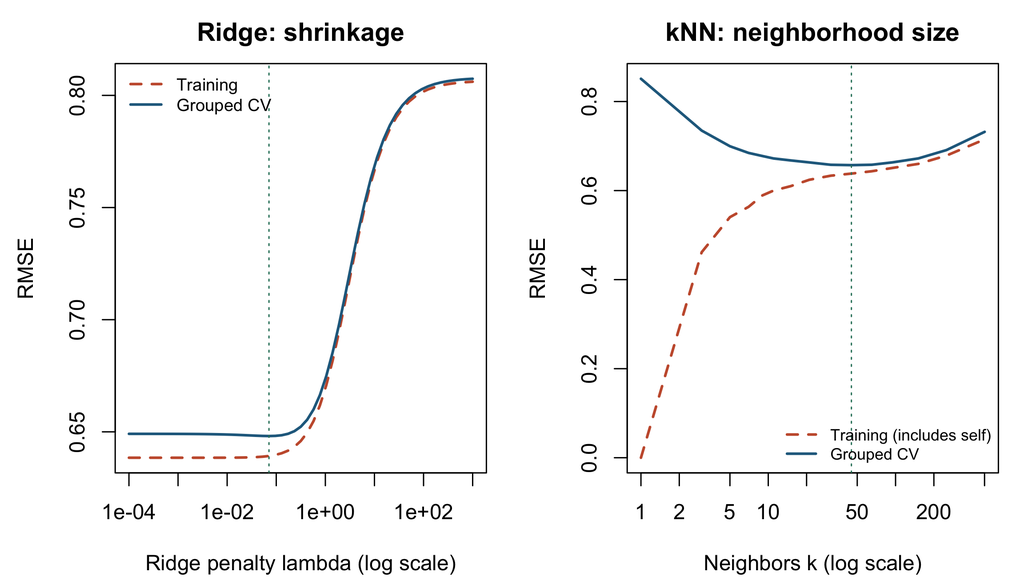

Training and grouped cross-validation error as model complexity changes. Vertical lines mark the selected settings.

```r
# Final training fits let us visualize the gap between fit and generalization.
final_scaler <- fit_scaler(train_x)
z_train <- apply_scaler(train_x, final_scaler)
ridge_training <- ridge_path(z_train, train_y, z_train, lambdas)
knn_training <- knn_path(z_train, train_y, z_train, ks)
ridge_train_rmse <- sqrt(colMeans(sweep(ridge_training$pred, 1, train_y, "-")^2))
knn_train_rmse <- sqrt(colMeans(sweep(knn_training, 1, train_y, "-")^2))

par(mfrow = c(1, 2), mar = c(4.5, 4.5, 2.5, 1))
positive <- lambdas > 0
matplot(lambdas[positive], cbind(ridge_train_rmse[positive], ridge_cv[positive]),
        type = "l", log = "x", lty = c(2, 1), col = c(orange, blue), lwd = 2,
        xlab = "Ridge penalty lambda (log scale)", ylab = "RMSE",
        main = "Ridge: shrinkage")
abline(v = best_lambda, lty = 3, col = green)
legend("topleft", c("Training", "Grouped CV"), col = c(orange, blue),
       lty = c(2, 1), lwd = 2, bty = "n", cex = .8)
matplot(ks, cbind(knn_train_rmse, knn_cv), type = "l", log = "x",
        lty = c(2, 1), col = c(orange, blue), lwd = 2,
        xlab = "Neighbors k (log scale)", ylab = "RMSE",
        main = "kNN: neighborhood size")
abline(v = best_k, lty = 3, col = green)
legend("bottomright", c("Training (includes self)", "Grouped CV"),
       col = c(orange, blue), lty = c(2, 1), lwd = 2, bty = "n", cex = .75)
```

```r
par(mfrow = c(1, 1))

# Store the full grids and fold variation for independent inspection.
write.csv(data.frame(lambda = lambdas, training_RMSE = ridge_train_rmse,
                     CV_RMSE = ridge_cv,
                     SD_fold_RMSE = apply(ridge_fold_rmse, 2, sd)),
          "results/ridge_tuning.csv", row.names = FALSE)
write.csv(data.frame(k = ks, training_RMSE = knn_train_rmse,
                     CV_RMSE = knn_cv,
                     SD_fold_RMSE = apply(knn_fold_rmse, 2, sd)),
          "results/knn_tuning.csv", row.names = FALSE)
```

For ridge, validation RMSE changes from 0.649 at zero penalty to 0.648 at the selected penalty and 0.807 at the largest penalty. Strong shrinkage pushes the model toward a constant and causes underfitting. The CV improvement over OLS is only 0.0010 points of RMSE, so regularization adds little predictive value beyond this linear fit. Ridge is not guaranteed to improve every dataset. Thse curves demonstrate training/generalization behavior, not a numerical decomposition of bias and variance. Repeated CV folds overlap, so fold variation is descriptive rather than a set of independent observations or a confidence interval.

# 5 Held-out test performance

Only now are the fitted models applied to the test set. Each tuned method uses all training observations and the selected tuning parameter. The mean baseline predicts the training-set average for every test wine. OLS uses exactly the same predictors as ridge. Predictions are kept continuous and are neither rounded nor clipped.

I report RMSE (primary), mean absolute error (MAE), test R-squared, and the fraction of predictions within one score point of the observed outcome. Test R-squared is `1 - SSE / sum((y_test - mean(y_test))^2)`; it can be negative. The within-one measure is a supplementary tolerance measure, not exact classification accuracy. Because a constant prediction can be within one point for many middle-score wines, it must be interpreted alongside RMSE.

```r
# Test features are scaled using the full training statistics, never their own.
z_test <- apply_scaler(as.matrix(test[predictors]), final_scaler)
ridge_test <- ridge_path(z_train, train_y, z_test, lambdas)$pred
knn_test <- knn_path(z_train, train_y, z_test, ks[knn_best])[, 1]
test_prediction <- list(
  "Mean baseline" = rep(mean(train_y), nrow(test)),
  "OLS" = ridge_test[, 1], "Ridge" = ridge_test[, ridge_best], "kNN" = knn_test)
metrics <- function(actual, predicted) {
  error <- actual - predicted
  c(RMSE = sqrt(mean(error^2)), MAE = mean(abs(error)),
    R_squared = 1 - sum(error^2) / sum((actual - mean(actual))^2),
    Within_one = mean(abs(error) <= 1))
}
test_results <- data.frame(Model = names(test_prediction),
  do.call(rbind, lapply(test_prediction, function(p) metrics(test$quality, p))),
  row.names = NULL)
knitr::kable(test_results, digits = 4,
             caption = "Held-out test results; lower RMSE/MAE is better.")
```

Held-out test results; lower RMSE/MAE is better.

| Model | RMSE | MAE | R_squared | Within_one |
| --- | --- | --- | --- | --- |
| Mean baseline | 0.8134 | 0.6876 | -0.0400 | 0.7969 |
| OLS | 0.6811 | 0.5330 | 0.2708 | 0.8738 |
| Ridge | 0.6801 | 0.5329 | 0.2729 | 0.8769 |
| kNN | 0.6774 | 0.5446 | 0.2786 | 0.8769 |

```r
write.csv(test_results, "results/test_metrics.csv", row.names = FALSE)
test_export <- data.frame(row_id = which(!in_train), group_id = g_test,
                          actual = test$quality, check.names = FALSE)
for (nm in names(test_prediction)) test_export[[nm]] <- test_prediction[[nm]]
write.csv(test_export, "results/test_predictions.csv", row.names = FALSE)

# All narrative numbers below are computed from the actual model outputs.
selected_prediction <- test_prediction[[selected_family]]
selected_result <- test_results[test_results$Model == selected_family, ]
baseline_result <- test_results[test_results$Model == "Mean baseline", ]
rmse_reduction <- 100 * (1 - selected_result$RMSE / baseline_result$RMSE)
```

The model chosen by CV, **Ridge**, obtains test RMSE **0.680 quality points**, MAE **0.533**, and test R-squared **0.273**. Its RMSE is **16.4% lower than the training-mean baseline**. The mean absolute error means predictions miss by about 0.53 score points on average; it does not mean that every prediction is within that distance. The within-one fraction is 87.7%, compared with 79.7% for the baseline.

kNN’s test RMSE is 0.6774, slightly below ridge’s 0.6801. Teh test ordering therefore differs from CV; switching models after seeing this result would turn the test set into another selection set. Ridge also improves on OLS by only 0.0009 points of test RMSE. The main gain here comes from using the measured predictors rather than from ridge regularization itself.

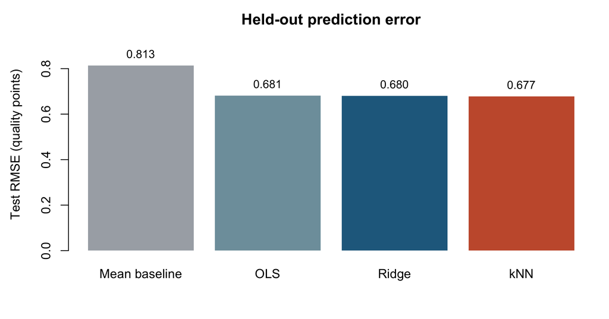

Test RMSE for the baseline, OLS, and the two tuned models.

```r
par(mar = c(4.5, 4.5, 2.5, 1))
bar_centers <- barplot(test_results$RMSE, names.arg = test_results$Model,
                      col = c("#A8ADB3", "#7E9EAA", blue, orange), border = NA,
                      ylim = c(0, max(test_results$RMSE) * 1.15),
                      ylab = "Test RMSE (quality points)", main = "Held-out prediction error")
text(bar_centers, test_results$RMSE,
     labels = fmt(test_results$RMSE), pos = 3, cex = .9)
```

# 6 Interpretation and diagnostic plots

## 6.1 Ridge coefficients and shrinkage

Ridge coefficients below represent a one-training-SD increase in a predictor, holding other measured predictors fixed. They are conditional associations, not experimental effects. Correlated predictors share information, so their individual coefficient signs and ranks should not be treated as a unique ranking of chemical importance. Ridge shrinks the coefficient vector overall; individual slopes need not shrink monotonically when predictors are correlated.

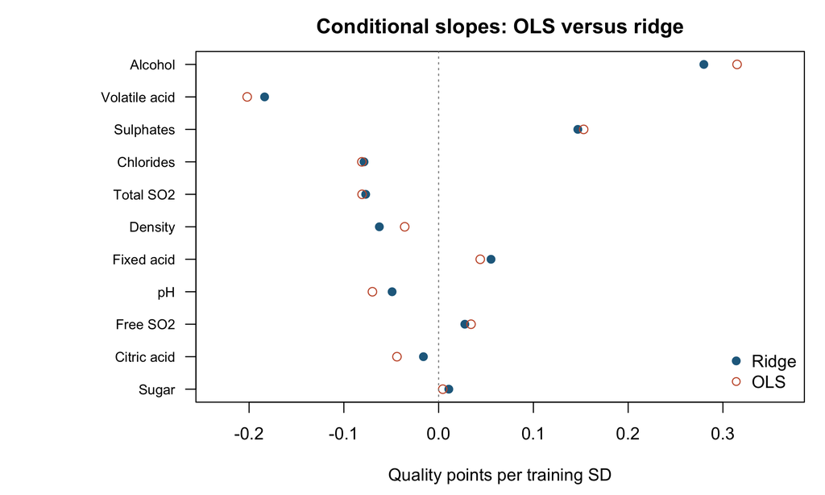

OLS and ridge slopes on the same standardized predictor scale.

```r
ridge_beta <- ridge_training$beta[, ridge_best]
ols_beta <- ridge_training$beta[, 1]
coefficient_table <- data.frame(Variable = predictors, OLS = ols_beta,
                               Ridge = ridge_beta, row.names = NULL)
ordered <- order(abs(ridge_beta))
par(mar = c(4.5, 9.5, 2.5, 1))
plot(ridge_beta[ordered], seq_along(ordered), pch = 19, col = blue,
     xlim = range(c(ols_beta, ridge_beta, 0)) * 1.15,
     yaxt = "n", ylab = "", xlab = "Quality points per training SD",
     main = "Conditional slopes: OLS versus ridge")
axis(2, at = seq_along(ordered), labels = short_names[ordered], las = 1, cex.axis = .8)
points(ols_beta[ordered], seq_along(ordered), pch = 1, col = orange, cex = 1.1)
abline(v = 0, lty = 3, col = "gray55")
legend("bottomright", c("Ridge", "OLS"), col = c(blue, orange), pch = c(19, 1), bty = "n")
```

```r
write.csv(coefficient_table, "results/standardized_coefficients.csv", row.names = FALSE)
strongest_positive <- names(which.max(ridge_beta))
strongest_negative <- names(which.min(ridge_beta))
```

The largest positive standardized ridge slope is for **alcohol** (0.280 score points per training SD), and the most negative is for **volatile.acidity** (-0.184). This describes conditional relationships in the fitted sample. It cannot show that deliberately increasing or decreasing a chemical would improve sensory quality.

## 6.2 Prediction quality across the score range

The observed-versus-predicted plot should lie near the diagonal for a strong model. Vertical separation from the diagonal is error. A horizontal concentration of predictions near the middle would indicate regression toward typical scores. The residual plot uses `observed - predicted`, so positive residuals mean underprediction and negative residuals mean overprediction. Horizontal jitter only separates overlapping integer scores visually; no metric uses jittered data.

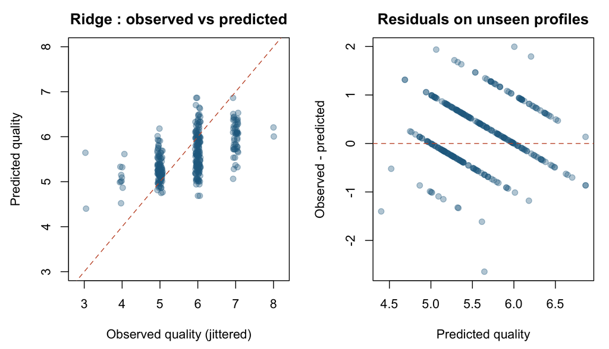

Held-out diagnostics for the family selected by cross-validation.

```r
par(mfrow = c(1, 2), mar = c(4.5, 4.5, 2.5, 1))
set.seed(405)
plot(jitter(test$quality, amount = .07), selected_prediction,
     pch = 19, col = adjustcolor(blue, alpha.f = .35),
     xlim = c(2.8, 8.2), ylim = range(c(3, 8, selected_prediction)),
     xlab = "Observed quality (jittered)", ylab = "Predicted quality",
     main = paste(selected_family, ": observed vs predicted"))
abline(0, 1, lty = 2, col = orange)
residual <- test$quality - selected_prediction
plot(selected_prediction, residual, pch = 19,
     col = adjustcolor(blue, alpha.f = .35),
     xlab = "Predicted quality", ylab = "Observed - predicted",
     main = "Residuals on unseen profiles")
abline(h = 0, lty = 2, col = orange)
```

```r
par(mfrow = c(1, 1))

# Score-specific errors expose performance hidden by an overall average.
by_score <- do.call(rbind, lapply(sort(unique(test$quality)), function(score) {
  rows <- test$quality == score
  data.frame(Observed_score = score, N = sum(rows),
             Mean_prediction = mean(selected_prediction[rows]),
             Mean_residual = mean(residual[rows]),
             MAE = mean(abs(residual[rows])))
}))
knitr::kable(by_score, digits = 3, row.names = FALSE,
             caption = paste("Test diagnostics by observed score for", selected_family))
```

Test diagnostics by observed score for Ridge

| Observed_score | N | Mean_prediction | Mean_residual | MAE |
| --- | --- | --- | --- | --- |
| 3 | 2 | 5.023 | -2.023 | 2.023 |
| 4 | 10 | 5.090 | -1.090 | 1.090 |
| 5 | 107 | 5.287 | -0.287 | 0.315 |
| 6 | 152 | 5.678 | 0.322 | 0.454 |
| 7 | 52 | 6.004 | 0.996 | 0.996 |
| 8 | 2 | 6.106 | 1.894 | 1.894 |

```r
write.csv(by_score, "results/errors_by_score.csv", row.names = FALSE)
```

At the lowest observed test score (3), the average prediction is 5.02; at the highest score (8), it is 6.11. These values show how well the extremes are recovered rather than relying only on the many scores in the middle. Rare-score rows in the table have small sample sizes, so their error estimates are especially unstable. Residual patterns can suggest missed structure, but this held-out inspection is diagnostic only: the present models are not retuned using it. The parallel diagonal bands in the residual plot arise mechanically because the observed score is an integer: for each fixed score, residual equals that score minus the prediction. The bands alone do not demonstrate nonlinearity.

# 7 Conclusions and limitations

The analysis answers the research question with a reproducible comparison: **Ridge was selected by repeated grouped CV and achieved test RMSE 0.680**, versus 0.813 for a training-mean prediction. This is a 16.4% reduction in RMSE. Chemical measurements contain predictive information, but the remaining errors and score-specific diagnostics show that they do not fully determine expert sensory scores.

The complexity curves explain why good training fit is insufficient. A tiny kNN neighborhood can follow individual training observations; an excessively large neighborhood loses local information. Ridge instead trades coefficient flexibility for stability, and heavy shrinkage ultimately underfits. The appropriate balance was estimated from held-out training folds, not from the test set.

Several limitations remain:

- **Ordered response:** treating scores as numeric assumes equal score intervals. An ordinal model would be a reasonable future comparison.
- **Population and dependence:** these results apply to similar red Vinho Verde profiles. Winery, batch, vintage, and sample IDs are unavailable. Grouping exact profiles cannot account for all possible dependence, nor guarantee performance on future vintages, white wines, or other regions.
- **Imbalanced scores:** common middle scores dominate average errors; rare extreme-score performance is less reliable. No artificial balancing was used because this analysis targets the original score distribution.
- **Model assumptions:** ridge uses additive linear relationships; kNN uses equal-weight Euclidean distances and is sensitive to irrelevant dimensions. Neither model explicitly handles all possible interactions or measurement noise.
- **Evaluation uncertainty:** there is one outer train/test split. Repeated inner CV reduces sensitivity to fold assignment, but does not remove tuning optimism.
- **Association:** coefficients are not causal effects. Missing information about grapes, brands, and other context may explain part of the residual error.

A useful extension would repeat the outer grouped split or use nested grouped cross-validation to assess the stability of the selected family. Batch or vintage identifiers would enable a more realistic external validation. Those extensions should use fresh validation data rather than repeatedly optimizing against the test set reported here.

# 8 Reproduction and references

The analysis uses base R for modeling, with knitr and rmarkdown for reporting. To reproduce the report, place wine_quality_report.Rmd and winequality-red.csv in teh same folder, open the R Markdown file in RStudio, and click Knit. The code regenerates the plots and supporting result files automatically.

**Data and provenance**

1. Cortez, P., Cerdeira, A., Almeida, F., Matos, T., & Reis, J. (2009). *Wine Quality* [Dataset]. UCI Machine Learning Repository. [Dataset DOI: 10.24432/C56S3T](https://doi.org/10.24432/C56S3T).
2. Cortez, P., Cerdeira, A., Almeida, F., Matos, T., & Reis, J. (2009). Modeling wine preferences by data mining from physicochemical properties. *Decision Support Systems, 47*(4), 547–553. [Article DOI: 10.1016/j.dss.2009.05.016](https://doi.org/10.1016/j.dss.2009.05.016).
3. Original files downloaded on November 1, 2026 from [UCI’s Wine Quality download](https://archive.ics.uci.edu/static/public/186/wine+quality.zip). Only winequality-red.csv is modeled. The original dataset is included unchanged. [CC BY 4.0 license](https://creativecommons.org/licenses/by/4.0/).

**Method reference**

4. James, G., Witten, D., Hastie, T., & Tibshirani, R. (2021). *An Introduction to Statistical Learning, with Applications in R* (2nd ed.). Chapters 2, 5, and 6 discuss flexibility, cross-validation, and regularization. [Official book site](https://www.statlearning.com/).

# 9 AI Use

for this project AI was used to find appropriate syntax etc. -like-> code folding etc AI was also used to check if my code ran smoothly and was prompted to make suggestions to iron out any kinks i may have had.